# Exploratory Analysis

## Introduction

The data set, [All Time Worldwide Box Office](https://www.kaggle.com/kkhandekar/all-time-worldwide-box-office), was collected from *The Numbers*. They are a free resource that has been tracking business information on movies since 1997, such as the name and rank of the movie, year it was released, and revenue. The data set records almost 600 movies with the highest box office revenues since 1939 up to 2021 reporting domestic, international, and worldwide sales.

## Summary

In the [All Time Worldwide Box Office](https://www.kaggle.com/kkhandekar/all-time-worldwide-box-office) data set, there are a total of **595** movies listed. For each of these movies, there are **6** different attributes listed within the data set. Of all the movies, there are **7** movies from foreign countries that made the list without having any sales domestically. Movies in the data set date all the way from **1939** to 2021. The **595** movies in the data set cumulatively have acquired a whopping **$312,316,769,990** in worldwide box office revenue!

## Table Visualization

Box Office Total for all Movies Per Year

| Year | Box_Office_Total |
| --- | --- |
| 1939 | 781050384 |
| 1942 | 536000000 |
| 1950 | 527182830 |
| 1965 | 572428390 |
| 1972 | 537000000 |
| 1973 | 856428956 |
| 1975 | 941400000 |
| 1977 | 2797196972 |
| 1978 | 1375367794 |
| 1980 | 1098002484 |
| 1981 | 734904158 |
| 1982 | 1585925944 |
| 1983 | 950212354 |
| 1984 | 1889184164 |
| 1985 | 1888242130 |
| 1986 | 1370430902 |
| 1987 | 1193530072 |
| 1988 | 2106200000 |
| 1989 | 3029185222 |
| 1990 | 4224919682 |
| 1991 | 3842258530 |
| 1992 | 3604538720 |
| 1993 | 5399424758 |
| 1994 | 6049346514 |
| 1995 | 6489328292 |
| 1996 | 7185269988 |
| 1997 | 11020165626 |
| 1998 | 7849509050 |
| 1999 | 11669817836 |
| 2000 | 9099028214 |
| 2001 | 13716401030 |
| 2002 | 14356133666 |
| 2003 | 12394280478 |
| 2004 | 15863351758 |
| 2005 | 14099083072 |
| 2006 | 14568024540 |
| 2007 | 20032467588 |
| 2008 | 20722683536 |
| 2009 | 27929022160 |
| 2010 | 27561162230 |
| 2011 | 25305465858 |
| 2012 | 34343475630 |
| 2013 | 33370390012 |
| 2014 | 31126849922 |
| 2015 | 36863171290 |
| 2016 | 38231577632 |
| 2017 | 42370668392 |
| 2018 | 45221257068 |
| 2019 | 43820443158 |
| 2020 | 4950372254 |
| 2021 | 6583778740 |

## Charts

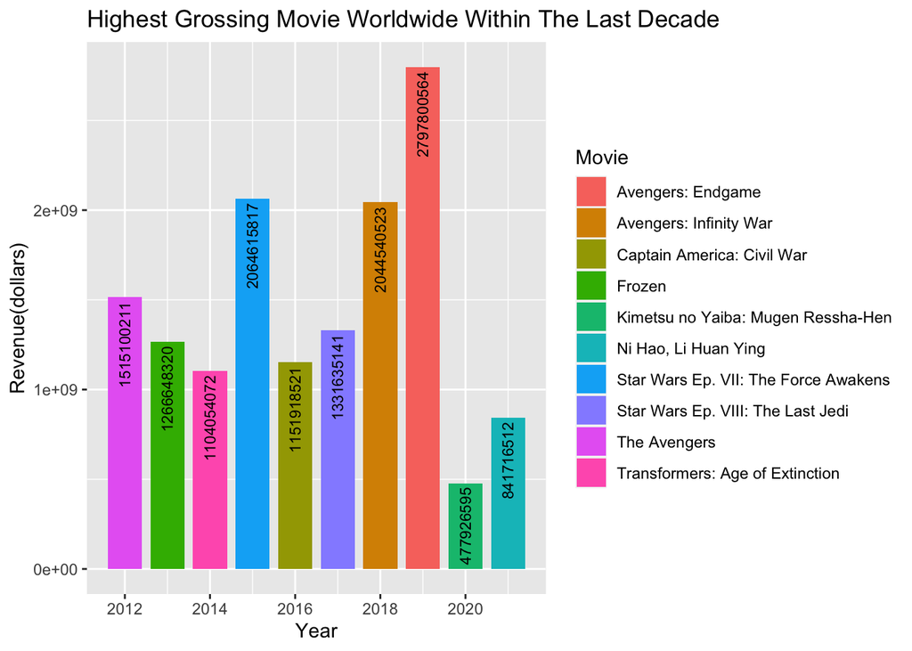

#### Graph Summary

This chart was intended to show the relationship between each of the highest grossing movies each year within the past decade. In 2019, *Avengers: Endgame* was the highest grossing film in the past decade, earning over $2.7 billion. The second highest grossing film was in 2015 for the movie, *Star Wars Ep. VII: The Force Awakens*, making over $2 billion as well. The success of these movies could have been due to the long awaited finales of their respective movie series, Avengers and Star Wars. Although, since 2020 there has been a dramatic decline in revenue, with *Kimetsu no Yaiba: Mugen Ressha-Hen* making over $470 million, possibly due to the Covid-19 pandemic causing many movie theaters to close down.

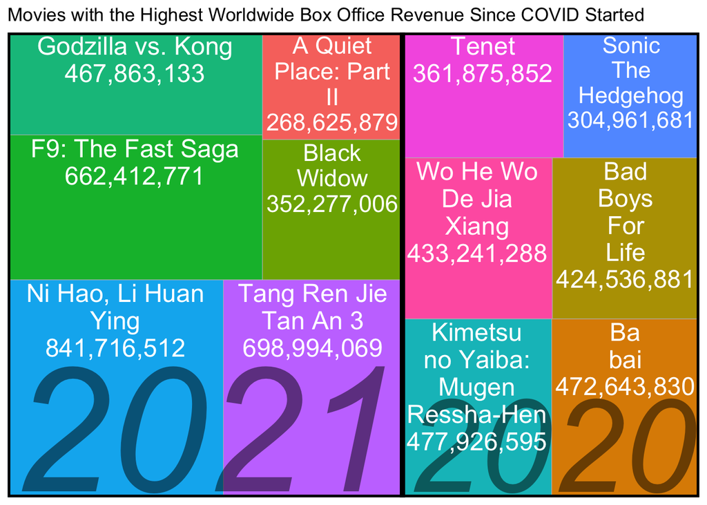

[figure not shown]

#### Graph Summary

The purpose of this chart is to show the most successful movies worldwide since the beginning of COVID (**2020-present**), using a tree map to show the proportions of each movie’s worldwide box office revenue. There were 6 movies in each year (**2020, 2021**) in the database for movies with the highest worldwide box office revenues. As you can see in the tree map, the top movies in **2021** take up a bigger proportion of the chart than **2020**, meaning that the top movies of **2021** were overall more successful in terms of worldwide box office revenue than **2020**. Something worth noting is that the movies that take up the most space on each year of the chart are movies from other countries.

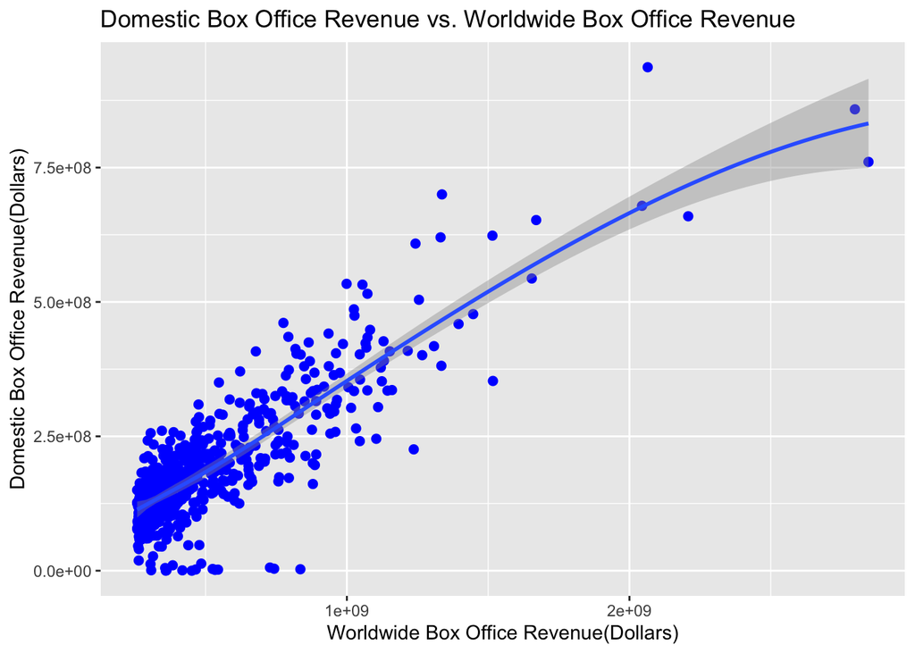

[figure not shown]

#### Graph Summary

This scatter plot is intended to show the relationship between how much the domestic box office revenue is, and the worldwide box office revenue. What this plot visualizes, is how much the domestic box office revenue is when the worldwide box office revenue is X. Per the chart and the best fit line, it seems to be a rather linear relationship, meaning as the worldwide box office revenue increases, the domestic box office revenue increases, *nearly* proportionally. The curve does seem to flatten out at the end, possibly meaning that as the worldwide box office revenue increases, the majority of the money starts to come from international box office sales.